# Annual Report Data Analysis - Question 3.09 and 3.10

Tristan Burgess and Cristin Young

2026-03-18

# 3. Did EBP/CDEP services impact clinical and functional outcomes for clients who participated?

**Inclusion criteria:** 1. must have initial time point data (i.e., be enrolled in an intervention), 2. must have a valid assessment collected at both intake and discharge time points, and 3. limited to tools with a clinical cut-off.

**Scoring:** An **increase** in score indicates a positive outcome. There are no benchmarks or clinical cutoffs established for NOMS scoring — if the follow-up assessment score is higher than the initial score, a positive outcome is indicated.

**Assumptions:** Filtered out dates before 2024-01-01 and after the date the code was run. Filtered data that’s >3 days from initial assessment and paired to the LAST follow-up. Filtered positive outcomes that had NAs before computing %.

## 3.09 To what extent did parents/caregivers report improved social connectedness for themselves and their child after receiving the intervention?

Range: 6–30; Sum = Q4a+…+Q4f.

Use the `pairs_primary_long_child` data frame to compute scores. The following had a positive outcome by follow-up quarter:

```
 positive_outcome   n percent
         worsened 109     15%
        no_change 224     32%
         improved 374     53%
```

Plot it.

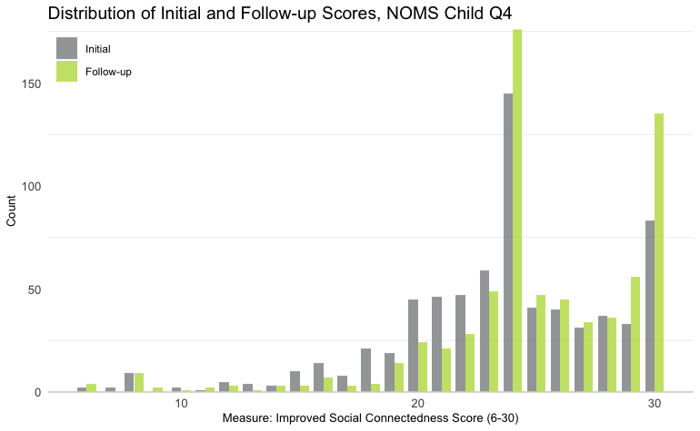

Ridgeline plot

| score_type | mean_score | median_score | sd_score | n |
| --- | --- | --- | --- | --- |
| Initial | 23.55587 | 24 | 4.617147 | 707 |
| Follow-up | 24.91655 | 24 | 4.497100 | 707 |

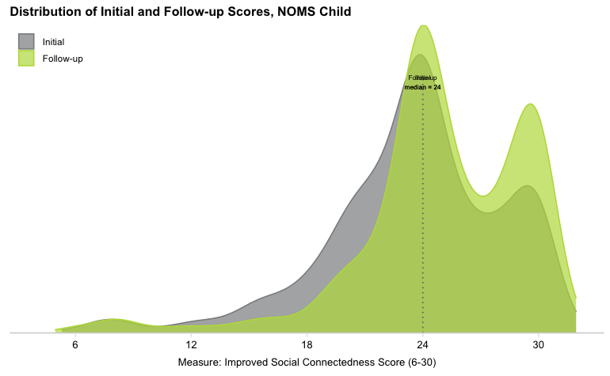

#### Summary stats

The percent of those who had total scores of 24 or higher (6*4) across Q4 at initial and discharge time points were:

| initial_24 | followup_24 |
| --- | --- |
| 57.99 | 74.82 |

## 3.10 To what extent did the youth report improved social connectedness after receiving the intervention?

Range: 6–30; Sum = Q4a+…+Q4f.

Use the `pairs_primary_long_self` data frame to compute scores. The following had a positive outcome by follow-up quarter:

```
 positive_outcome    n percent
         worsened 1093     46%
        no_change  267     11%
         improved 1033     43%
```

Plot it.

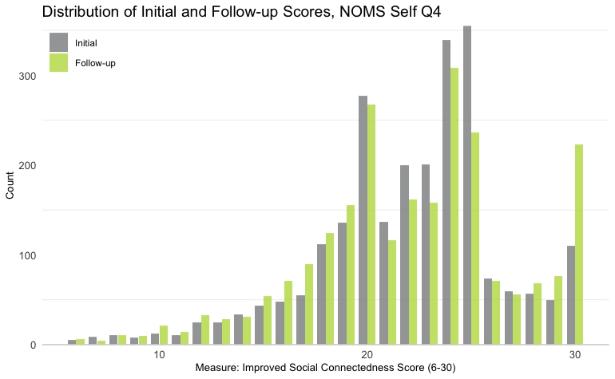

Ridgeline plot

| score_type | mean_score | median_score | sd_score | n | y_text |
| --- | --- | --- | --- | --- | --- |
| Initial | 22.08817 | 23 | 4.336321 | 2393 | 1.10 |
| Follow-up | 22.09570 | 22 | 4.883213 | 2393 | 1.11 |

[figure not shown]

#### Summary stats

The percent of those who selected ratings of 4 or higher (excellent or very good) across Q4 at initial and discharge time points were:

| initial_24 | followup_24 |
| --- | --- |
| 43.63 | 43.38 |

### Summary stats overall

[figure not shown]